# customer_segments project

## Project: Creating Customer Segments

The goal of this project is to best describe the variation in the different types of customers that a wholesale distributor interacts with. Doing so would equip the distributor with insight into how to best structure their delivery service to meet the needs of each customer.

The dataset for this project can be found on the [UCI Machine Learning Repository](https://archive.ics.uci.edu/ml/datasets/Wholesale+customers). For the purposes of this project, the features `'Channel'` and `'Region'` will be excluded in the analysis — with focus instead on the six product categories recorded for customers.

```python
# Import libraries necessary for this project
import numpy as np
import pandas as pd
from IPython.display import display # Allows the use of display() for DataFrames
import warnings
warnings.filterwarnings('ignore')
# Import supplementary visualizations code visuals.py
import visuals as vs

# Pretty display for notebooks
%matplotlib inline

# Load the wholesale customers dataset
try:
    data = pd.read_csv("customers.csv")
    data.drop(['Region', 'Channel'], axis = 1, inplace = True)
    print("Wholesale customers dataset has {} samples with {} features each.".format(*data.shape))
except:
    print("Dataset could not be loaded. Is the dataset missing?")
```

```
Wholesale customers dataset has 440 samples with 6 features each.
```

## Data Exploration

```python
# Display a description of the dataset
display(data.describe())
```

|  | Fresh | Milk | Grocery | Frozen | Detergents_Paper | Delicatessen |
| --- | --- | --- | --- | --- | --- | --- |
| count | 440.000000 | 440.000000 | 440.000000 | 440.000000 | 440.000000 | 440.000000 |
| mean | 12000.297727 | 5796.265909 | 7951.277273 | 3071.931818 | 2881.493182 | 1524.870455 |
| std | 12647.328865 | 7380.377175 | 9503.162829 | 4854.673333 | 4767.854448 | 2820.105937 |
| min | 3.000000 | 55.000000 | 3.000000 | 25.000000 | 3.000000 | 3.000000 |
| 25% | 3127.750000 | 1533.000000 | 2153.000000 | 742.250000 | 256.750000 | 408.250000 |
| 50% | 8504.000000 | 3627.000000 | 4755.500000 | 1526.000000 | 816.500000 | 965.500000 |
| 75% | 16933.750000 | 7190.250000 | 10655.750000 | 3554.250000 | 3922.000000 | 1820.250000 |
| max | 112151.000000 | 73498.000000 | 92780.000000 | 60869.000000 | 40827.000000 | 47943.000000 |

### Implementation: Selecting Samples

```python
# Select three indices of your choice you wish to sample from the dataset
indices = [18,199,351]

# Create a DataFrame of the chosen samples
samples = pd.DataFrame(data.loc[indices], columns = data.keys()).reset_index(drop = True)
print("Chosen samples of wholesale customers dataset:")
display(samples)
```

```
Chosen samples of wholesale customers dataset:
```

|  | Fresh | Milk | Grocery | Frozen | Detergents_Paper | Delicatessen |
| --- | --- | --- | --- | --- | --- | --- |
| 0 | 18601 | 6327 | 10099 | 2205 | 2767 | 3181 |
| 1 | 9670 | 2280 | 2112 | 520 | 402 | 347 |
| 2 | 1210 | 10044 | 22294 | 1741 | 12638 | 3137 |

### Observation 1

- #1: Local grocery store. For my first sample, the fresh and grocery purchases are above the average, where local Deli will purchase and sell a lot of fresh and grocery goods.
- #2: student. This customer made purchases on goods that are way below average level, average grocery is 7951, but this sample customer only spent 2112, which means that they do not need to do grocery very often, and student could be a good fit for this category.
- #3: Restaurant: The last sample customer consumes huge amount of grocery and detergent_papers, indicating that they could be a possible restaurant that need to purchase a lot of food and detergent papers for cleaning purpose.

### Implementation: Feature Relevance

To determine whether customers purchasing some amount of one category of products will necessarily purchase some proportional amount of another category of products. We can train a supervised regression learner on a subset of the data with one feature removed, and then score how well that model can predict the removed feature.

- Assign `new_data` a copy of the data by removing a feature of your choice using the `DataFrame.drop` function.
- Use `sklearn.cross_validation.train_test_split` to split the dataset into training and testing sets.
  - Use the removed feature as your target label. Set a `test_size` of `0.25` and set a `random_state`.
- Import a decision tree regressor, set a `random_state`, and fit the learner to the training data.
- Report the prediction score of the testing set using the regressor's `score` function.

```python
from sklearn.cross_validation import train_test_split
from sklearn.tree import DecisionTreeRegressor
new_data = data.drop(axis=1, columns=['Milk']).copy()
y = data['Milk']

# Set a random state.
X_train, X_test, y_train, y_test = train_test_split(new_data,
                                                    y,
                                                    test_size = 0.25,
                                                    random_state = 0)

regressor = DecisionTreeRegressor()
regressor.fit(X_train, y_train)
score = regressor.score(X_test, y_test)
print(score)
```

```
0.08894146449630225
```

### Visualize Feature Distributions

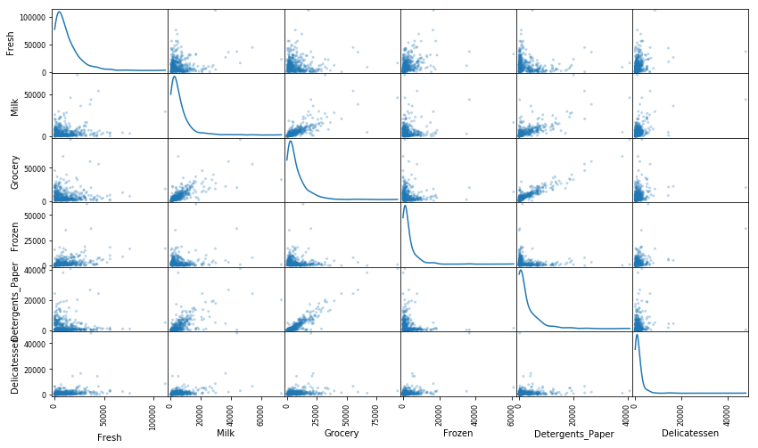

```python
# Produce a scatter matrix for each pair of features in the data
pd.scatter_matrix(data, alpha = 0.3, figsize = (14,8), diagonal = 'kde');
```

### Observation 3

From the correlation matrix, all the features are highly skewed to the right, with long tail on the right, and they are not normally distributed. Other than Grocery and Detergents_Paper features, all other features are not highly correlated with each other. Especially Milk and Grocery, Detergents_paper and Grocery, these two pairs have strong correlations with each other. The strong correlation between Milk and Grocery also support my suspicion that Milk will be a feature that is relevant in Customers’ choices.

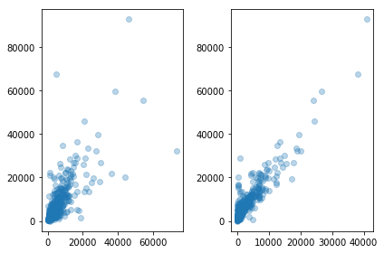

```python
import matplotlib.pyplot as plt
plt.subplot(1,2,1)
plt.scatter(data['Milk'], data['Grocery'],alpha= .3)
plt.subplot(1,2,2)
plt.scatter(data['Detergents_Paper'], data['Grocery'], alpha= .3)
plt.tight_layout()
plt.show()
```

## Data Preprocessing

### Implementation: Feature Scaling

- Assign a copy of the data to `log_data` after applying logarithmic scaling. Use the `np.log` function for this.
- Assign a copy of the sample data to `log_samples` after applying logarithmic scaling. Again, use `np.log`.

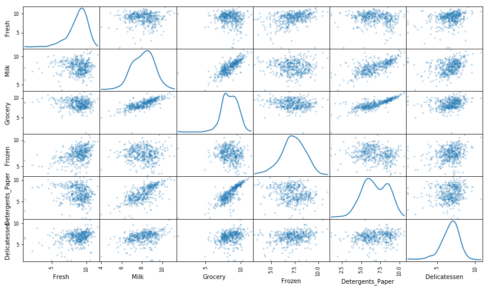

```python
# Scale the data using the natural logarithm
log_data = np.log(data)

# Scale the sample data using the natural logarithm
log_samples = pd.DataFrame(np.log(samples))

# Produce a scatter matrix for each pair of newly-transformed features
pd.scatter_matrix(log_data, alpha = 0.3, figsize = (14,8), diagonal = 'kde');
```

### Observation

```python
# Display the log-transformed sample data
display(log_samples)
```

|  | Fresh | Milk | Grocery | Frozen | Detergents_Paper | Delicatessen |
| --- | --- | --- | --- | --- | --- | --- |
| 0 | 9.830971 | 8.752581 | 9.220192 | 7.698483 | 7.925519 | 8.064951 |
| 1 | 9.176784 | 7.731931 | 7.655391 | 6.253829 | 5.996452 | 5.849325 |
| 2 | 7.098376 | 9.214731 | 10.012073 | 7.462215 | 9.444463 | 8.051022 |

### Implementation: Outlier Detection

Detecting outliers in the data is extremely important in the data preprocessing step of any analysis. The presence of outliers can often skew results which take into consideration these data points. There are many "rules of thumb" for what constitutes an outlier in a dataset. Here, we will use [Tukey's Method for identfying outliers](http://datapigtechnologies.com/blog/index.php/highlighting-outliers-in-your-data-with-the-tukey-method/): An *outlier step* is calculated as 1.5 times the interquartile range (IQR). A data point with a feature that is beyond an outlier step outside of the IQR for that feature is considered abnormal.

- Assign the value of the 25th percentile for the given feature to `Q1`. Use `np.percentile` for this.
- Assign the value of the 75th percentile for the given feature to `Q3`. Again, use `np.percentile`.
- Assign the calculation of an outlier step for the given feature to `step`.
- Optionally remove data points from the dataset by adding indices to the `outliers` list.

```python
# For each feature find the data points with extreme high or low values

index_list = []
for feature in log_data.keys():

    # Calculate Q1 (25th percentile of the data) for the given feature
    Q1 = np.percentile(log_data[feature], 25)

    # Calculate Q3 (75th percentile of the data) for the given feature
    Q3 = np.percentile(log_data[feature], 75)

    # Use the interquartile range to calculate an outlier step (1.5 times the interquartile range)
    step = (Q3 - Q1) * 1.5

    # Display the outliers
    print("Data points considered outliers for the feature '{}':".format(feature))
    index_list +=(log_data[~((log_data[feature] >= Q1 - step) & (log_data[feature] <= Q3 + step))].index.tolist())
    display(log_data[~((log_data[feature] >= Q1 - step) & (log_data[feature] <= Q3 + step))])

print(index_list)

print ("The below data points are outliers in multiple features:")
a = sorted({i for i in index_list if index_list.count(i) > 1})
print (a)

# remove the extras in idx
for i in a:
    index_list.remove(i)

# OPTIONAL: Select the indices for data points you wish to remove
outliers  = index_list

# Remove the outliers, if any were specified
good_data = log_data.drop(log_data.index[outliers]).reset_index(drop = True)

print('Follwing are the outlier list: ',outliers)

# Remove the outliers, if any were specified
good_data = log_data.drop(log_data.index[outliers]).reset_index(drop = True)
```

```
Data points considered outliers for the feature 'Fresh':
```

|  | Fresh | Milk | Grocery | Frozen | Detergents_Paper | Delicatessen |
| --- | --- | --- | --- | --- | --- | --- |
| 65 | 4.442651 | 9.950323 | 10.732651 | 3.583519 | 10.095388 | 7.260523 |
| 66 | 2.197225 | 7.335634 | 8.911530 | 5.164786 | 8.151333 | 3.295837 |
| 81 | 5.389072 | 9.163249 | 9.575192 | 5.645447 | 8.964184 | 5.049856 |
| 95 | 1.098612 | 7.979339 | 8.740657 | 6.086775 | 5.407172 | 6.563856 |
| 96 | 3.135494 | 7.869402 | 9.001839 | 4.976734 | 8.262043 | 5.379897 |
| 128 | 4.941642 | 9.087834 | 8.248791 | 4.955827 | 6.967909 | 1.098612 |
| 171 | 5.298317 | 10.160530 | 9.894245 | 6.478510 | 9.079434 | 8.740337 |
| 193 | 5.192957 | 8.156223 | 9.917982 | 6.865891 | 8.633731 | 6.501290 |
| 218 | 2.890372 | 8.923191 | 9.629380 | 7.158514 | 8.475746 | 8.759669 |
| 304 | 5.081404 | 8.917311 | 10.117510 | 6.424869 | 9.374413 | 7.787382 |
| 305 | 5.493061 | 9.468001 | 9.088399 | 6.683361 | 8.271037 | 5.351858 |
| 338 | 1.098612 | 5.808142 | 8.856661 | 9.655090 | 2.708050 | 6.309918 |
| 353 | 4.762174 | 8.742574 | 9.961898 | 5.429346 | 9.069007 | 7.013016 |
| 355 | 5.247024 | 6.588926 | 7.606885 | 5.501258 | 5.214936 | 4.844187 |
| 357 | 3.610918 | 7.150701 | 10.011086 | 4.919981 | 8.816853 | 4.700480 |
| 412 | 4.574711 | 8.190077 | 9.425452 | 4.584967 | 7.996317 | 4.127134 |

```
Data points considered outliers for the feature 'Milk':
```

|  | Fresh | Milk | Grocery | Frozen | Detergents_Paper | Delicatessen |
| --- | --- | --- | --- | --- | --- | --- |
| 86 | 10.039983 | 11.205013 | 10.377047 | 6.894670 | 9.906981 | 6.805723 |
| 98 | 6.220590 | 4.718499 | 6.656727 | 6.796824 | 4.025352 | 4.882802 |
| 154 | 6.432940 | 4.007333 | 4.919981 | 4.317488 | 1.945910 | 2.079442 |
| 356 | 10.029503 | 4.897840 | 5.384495 | 8.057377 | 2.197225 | 6.306275 |

```
Data points considered outliers for the feature 'Grocery':
```

|  | Fresh | Milk | Grocery | Frozen | Detergents_Paper | Delicatessen |
| --- | --- | --- | --- | --- | --- | --- |
| 75 | 9.923192 | 7.036148 | 1.098612 | 8.390949 | 1.098612 | 6.882437 |
| 154 | 6.432940 | 4.007333 | 4.919981 | 4.317488 | 1.945910 | 2.079442 |

```
Data points considered outliers for the feature 'Frozen':
```

|  | Fresh | Milk | Grocery | Frozen | Detergents_Paper | Delicatessen |
| --- | --- | --- | --- | --- | --- | --- |
| 38 | 8.431853 | 9.663261 | 9.723703 | 3.496508 | 8.847360 | 6.070738 |
| 57 | 8.597297 | 9.203618 | 9.257892 | 3.637586 | 8.932213 | 7.156177 |
| 65 | 4.442651 | 9.950323 | 10.732651 | 3.583519 | 10.095388 | 7.260523 |
| 145 | 10.000569 | 9.034080 | 10.457143 | 3.737670 | 9.440738 | 8.396155 |
| 175 | 7.759187 | 8.967632 | 9.382106 | 3.951244 | 8.341887 | 7.436617 |
| 264 | 6.978214 | 9.177714 | 9.645041 | 4.110874 | 8.696176 | 7.142827 |
| 325 | 10.395650 | 9.728181 | 9.519735 | 11.016479 | 7.148346 | 8.632128 |
| 420 | 8.402007 | 8.569026 | 9.490015 | 3.218876 | 8.827321 | 7.239215 |
| 429 | 9.060331 | 7.467371 | 8.183118 | 3.850148 | 4.430817 | 7.824446 |
| 439 | 7.932721 | 7.437206 | 7.828038 | 4.174387 | 6.167516 | 3.951244 |

```
Data points considered outliers for the feature 'Detergents_Paper':
```

|  | Fresh | Milk | Grocery | Frozen | Detergents_Paper | Delicatessen |
| --- | --- | --- | --- | --- | --- | --- |
| 75 | 9.923192 | 7.036148 | 1.098612 | 8.390949 | 1.098612 | 6.882437 |
| 161 | 9.428190 | 6.291569 | 5.645447 | 6.995766 | 1.098612 | 7.711101 |

```
Data points considered outliers for the feature 'Delicatessen':
```

|  | Fresh | Milk | Grocery | Frozen | Detergents_Paper | Delicatessen |
| --- | --- | --- | --- | --- | --- | --- |
| 66 | 2.197225 | 7.335634 | 8.911530 | 5.164786 | 8.151333 | 3.295837 |
| 109 | 7.248504 | 9.724899 | 10.274568 | 6.511745 | 6.728629 | 1.098612 |
| 128 | 4.941642 | 9.087834 | 8.248791 | 4.955827 | 6.967909 | 1.098612 |
| 137 | 8.034955 | 8.997147 | 9.021840 | 6.493754 | 6.580639 | 3.583519 |
| 142 | 10.519646 | 8.875147 | 9.018332 | 8.004700 | 2.995732 | 1.098612 |
| 154 | 6.432940 | 4.007333 | 4.919981 | 4.317488 | 1.945910 | 2.079442 |
| 183 | 10.514529 | 10.690808 | 9.911952 | 10.505999 | 5.476464 | 10.777768 |
| 184 | 5.789960 | 6.822197 | 8.457443 | 4.304065 | 5.811141 | 2.397895 |
| 187 | 7.798933 | 8.987447 | 9.192075 | 8.743372 | 8.148735 | 1.098612 |
| 203 | 6.368187 | 6.529419 | 7.703459 | 6.150603 | 6.860664 | 2.890372 |
| 233 | 6.871091 | 8.513988 | 8.106515 | 6.842683 | 6.013715 | 1.945910 |
| 285 | 10.602965 | 6.461468 | 8.188689 | 6.948897 | 6.077642 | 2.890372 |
| 289 | 10.663966 | 5.655992 | 6.154858 | 7.235619 | 3.465736 | 3.091042 |
| 343 | 7.431892 | 8.848509 | 10.177932 | 7.283448 | 9.646593 | 3.610918 |

```
[65, 66, 81, 95, 96, 128, 171, 193, 218, 304, 305, 338, 353, 355, 357, 412, 86, 98, 154, 356, 75, 154, 38, 57, 65, 145, 175, 264, 325, 420, 429, 439, 75, 161, 66, 109, 128, 137, 142, 154, 183, 184, 187, 203, 233, 285, 289, 343]
The below data points are outliers in multiple features:
[65, 66, 75, 128, 154]
Follwing are the outlier list:  [81, 95, 96, 171, 193, 218, 304, 305, 338, 353, 355, 357, 412, 86, 98, 356, 154, 38, 57, 65, 145, 175, 264, 325, 420, 429, 439, 75, 161, 66, 109, 128, 137, 142, 154, 183, 184, 187, 203, 233, 285, 289, 343]
```

```python
data.iloc[[65,66,128,154],]
```

|  | Fresh | Milk | Grocery | Frozen | Detergents_Paper | Delicatessen |
| --- | --- | --- | --- | --- | --- | --- |
| 65 | 85 | 20959 | 45828 | 36 | 24231 | 1423 |
| 66 | 9 | 1534 | 7417 | 175 | 3468 | 27 |
| 128 | 140 | 8847 | 3823 | 142 | 1062 | 3 |
| 154 | 622 | 55 | 137 | 75 | 7 | 8 |

## Feature Transformation

### Implementation: PCA

Now that the data has been scaled to a more normal distribution and has had any necessary outliers removed, we can now apply PCA to the `good_data` to discover which dimensions about the data best maximize the variance of features involved. In addition to finding these dimensions, PCA will also report the *explained variance ratio* of each dimension — how much variance within the data is explained by that dimension alone. Note that a component (dimension) from PCA can be considered a new "feature" of the space, however it is a composition of the original features present in the data.

- Import `sklearn.decomposition.PCA` and assign the results of fitting PCA in six dimensions with `good_data` to `pca`.
- Apply a PCA transformation of `log_samples` using `pca.transform`, and assign the results to `pca_samples`.

```
Variance explained by the first principal component: 0.4993048380748743
Variance explained by the second principal component: 0.22594806679148566
Total variance explained by the first two principal components: 0.72525290486636
Total variance explained by the first four principal components: 0.9279536052307858
```

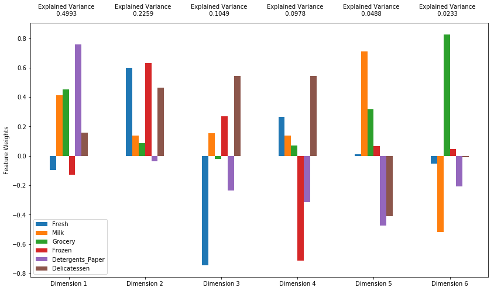

```python
# Apply PCA by fitting the good data with the same number of dimensions as features
from sklearn.decomposition import PCA
num_feature = len(good_data.columns)

pca = PCA(n_components=num_feature).fit(good_data)
# Transform log_samples using the PCA fit above
pca_samples = pca.transform(log_samples)

# Generate PCA results plot
pca_results = vs.pca_results(good_data, pca)

# pca.explained_variance_ratio_

fir_var_exp = pca.explained_variance_ratio_[0]
sec_var_exp = pca.explained_variance_ratio_[1]

first_two_var_explained = sum(pca.explained_variance_ratio_[:2])
first_four_var_explained = sum(pca.explained_variance_ratio_[:4])

print('Variance explained by the first principal component: {}'.format(fir_var_exp))
print('Variance explained by the second principal component: {}'.format(sec_var_exp))
print('Total variance explained by the first two principal components: {}'.format(first_two_var_explained))
print('Total variance explained by the first four principal components: {}'.format(first_four_var_explained))
```

### Observation 5

In total, the variance explained by the first two principal components is 0.7253, and first four principal components explained 0.9279 of the total variance.

### Observation

```python
# Display sample log-data after having a PCA transformation applied
display(pd.DataFrame(np.round(pca_samples, 4), columns = pca_results.index.values))
```

|  | Dimension 1 | Dimension 2 | Dimension 3 | Dimension 4 | Dimension 5 | Dimension 6 |
| --- | --- | --- | --- | --- | --- | --- |
| 0 | 1.5627 | 1.4065 | -0.0979 | 0.5199 | -0.3294 | 0.0511 |
| 1 | -1.1286 | -1.1240 | -0.8700 | 0.5270 | 0.1726 | -0.3244 |
| 2 | 3.5582 | -0.3169 | 1.5663 | -0.4077 | -0.5108 | 0.2878 |

### Implementation: Dimensionality Reduction

When using principal component analysis, one of the main goals is to reduce the dimensionality of the data — in effect, reducing the complexity of the problem. Dimensionality reduction comes at a cost: Fewer dimensions used implies less of the total variance in the data is being explained. Because of this, the *cumulative explained variance ratio* is extremely important for knowing how many dimensions are necessary for the problem. Additionally, if a signifiant amount of variance is explained by only two or three dimensions, the reduced data can be visualized afterwards.

- Assign the results of fitting PCA in two dimensions with `good_data` to `pca`.
- Apply a PCA transformation of `good_data` using `pca.transform`, and assign the results to `reduced_data`.
- Apply a PCA transformation of `log_samples` using `pca.transform`, and assign the results to `pca_samples`.

```python
# Apply PCA by fitting the good data with only two dimensions
pca = PCA(n_components=2).fit(good_data)

# Transform the good data using the PCA fit above
reduced_data = pca.transform(good_data)

# Transform log_samples using the PCA fit above
pca_samples = pca.transform(log_samples)

# Create a DataFrame for the reduced data
reduced_data = pd.DataFrame(reduced_data, columns = ['Dimension 1', 'Dimension 2'])
```

### Observation

```python
# Display sample log-data after applying PCA transformation in two dimensions
display(pd.DataFrame(np.round(pca_samples, 4), columns = ['Dimension 1', 'Dimension 2']))
```

|  | Dimension 1 | Dimension 2 |
| --- | --- | --- |
| 0 | 1.5627 | 1.4065 |
| 1 | -1.1286 | -1.1240 |
| 2 | 3.5582 | -0.3169 |

## Visualizing a Biplot

A biplot is a scatterplot where each data point is represented by its scores along the principal components. The axes are the principal components (in this case `Dimension 1` and `Dimension 2`). In addition, the biplot shows the projection of the original features along the components. A biplot can help us interpret the reduced dimensions of the data, and discover relationships between the principal components and original features.

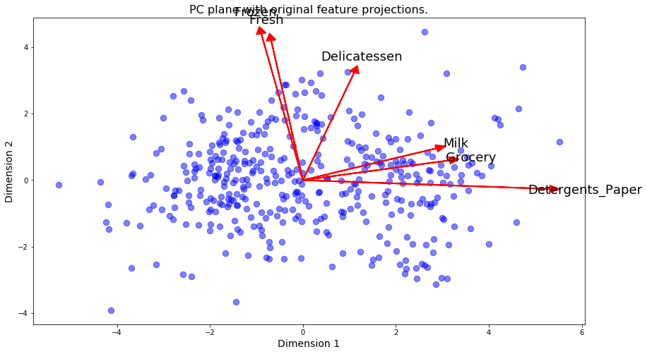

```python
# Create a biplot
vs.biplot(good_data, reduced_data, pca)
```

### Observation

Once we have the original feature projections (in red), it is easier to interpret the relative position of each data point in the scatterplot. For instance, a point the lower right corner of the figure will likely correspond to a customer that spends a lot on `'Milk'`, `'Grocery'` and `'Detergents_Paper'`, but not so much on the other product categories.

## Clustering

### Observation 6

Model selection

K-Means Clustering Algorithm Advantage:

1. It is easy to implement
2. Fast without using a lot computations.
3. It produce tighter clusters than hierarchical clustering.

Gaussian Mixture Model clustering algorithm advantage:

1. Do not assume cluster and work well with non-linear distribution.
2. Do not have the bias on the cluster size
3. Work well for soft assignment, the uncertainty of points belong to which cluster.

Given current understanding of the data, I would choose Gaussian Mixture Model. The main reason is that GMM works better for soft assignments. As for our customer data, it is not quite clear that we have certain clusters among the data points, and for the densely packed areas, for example, milk, grocery and detergent paper seems to have strong correlation with each other, while clustering them, could incur a lot of uncertainties, and in this case GMM will do a better job in creating clusters.

### Implementation: Creating Clusters

- Fit a clustering algorithm to the `reduced_data` and assign it to `clusterer`.
- Predict the cluster for each data point in `reduced_data` using `clusterer.predict` and assign them to `preds`.
- Find the cluster centers using the algorithm's respective attribute and assign them to `centers`.
- Predict the cluster for each sample data point in `pca_samples` and assign them `sample_preds`.
- Import `sklearn.metrics.silhouette_score` and calculate the silhouette score of `reduced_data` against `preds`.
  - Assign the silhouette score to `score` and print the result.

```python
from sklearn.mixture import GMM
from sklearn.metrics import silhouette_score

cluster_num = [2,3,4,5,6]

def gmm_cluster(cluster_num):
    for i in cluster_num:
        clusterer = GMM(n_components=i).fit(reduced_data)
        preds = clusterer.predict(reduced_data)
        centers = clusterer.means_
        sample_preds = clusterer.predict(pca_samples)
        score =  silhouette_score(reduced_data,preds)
        print('For cluster of {} the score is: {}'.format(i,score))


gmm_cluster(cluster_num)
```

```
For cluster of 2 the score is: 0.4436014740151462
For cluster of 3 the score is: 0.35505321951057794
For cluster of 4 the score is: 0.29164636837674707
For cluster of 5 the score is: 0.2683982070363696
For cluster of 6 the score is: 0.3071228664473279
```

### Observation 7

Based on the result, using 2 clusters, we can acheive the best result

### Cluster Visualization

```python
# Apply your clustering algorithm of choice to the reduced data
clusterer = GMM(n_components = 2)
clusterer.fit(reduced_data)

# Predict the cluster for each data point
preds = clusterer.predict(reduced_data)

# Find the cluster centers
centers = clusterer.means_

# Predict the cluster for each transformed sample data point
sample_preds = clusterer.predict(pca_samples)

# Calculate the mean silhouette coefficient for the number of clusters chosen
from sklearn.metrics import silhouette_score
score = silhouette_score(reduced_data, preds)
print(score)
```

```
0.4436014740151462
```

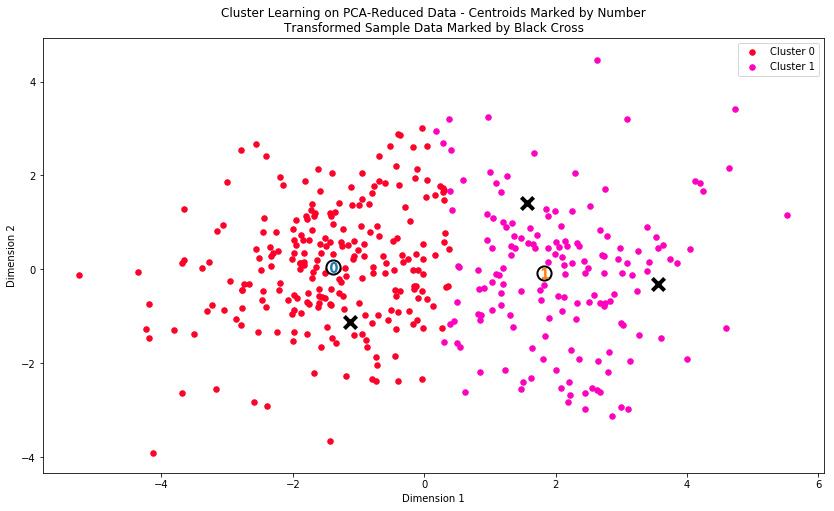

```python
# Display the results of the clustering from implementation
vs.cluster_results(reduced_data, preds, centers, pca_samples)
```

### Implementation: Data Recovery

Each cluster present in the visualization above has a central point. These centers (or means) are not specifically data points from the data, but rather the *averages* of all the data points predicted in the respective clusters. For the problem of creating customer segments, a cluster's center point corresponds to *the average customer of that segment*. Since the data is currently reduced in dimension and scaled by a logarithm, we can recover the representative customer spending from these data points by applying the inverse transformations.

- Apply the inverse transform to `centers` using `pca.inverse_transform` and assign the new centers to `log_centers`.
- Apply the inverse function of `np.log` to `log_centers` using `np.exp` and assign the true centers to `true_centers`.

```python
# Inverse transform the centers
log_centers = pca.inverse_transform(centers)


# Exponentiate the centers
true_centers = np.exp(log_centers)


# Display the true centers
segments = ['Segment {}'.format(i) for i in range(0,len(centers))]
true_centers = pd.DataFrame(np.round(true_centers), columns = data.keys())
true_centers.index = segments
display(true_centers)
```

|  | Fresh | Milk | Grocery | Frozen | Detergents_Paper | Delicatessen |
| --- | --- | --- | --- | --- | --- | --- |
| Segment 0 | 8967.0 | 1920.0 | 2437.0 | 2081.0 | 309.0 | 741.0 |
| Segment 1 | 6079.0 | 7042.0 | 10241.0 | 1275.0 | 3546.0 | 1159.0 |

```python
data.describe()
```

|  | Fresh | Milk | Grocery | Frozen | Detergents_Paper | Delicatessen |
| --- | --- | --- | --- | --- | --- | --- |
| count | 440.000000 | 440.000000 | 440.000000 | 440.000000 | 440.000000 | 440.000000 |
| mean | 12000.297727 | 5796.265909 | 7951.277273 | 3071.931818 | 2881.493182 | 1524.870455 |
| std | 12647.328865 | 7380.377175 | 9503.162829 | 4854.673333 | 4767.854448 | 2820.105937 |
| min | 3.000000 | 55.000000 | 3.000000 | 25.000000 | 3.000000 | 3.000000 |
| 25% | 3127.750000 | 1533.000000 | 2153.000000 | 742.250000 | 256.750000 | 408.250000 |
| 50% | 8504.000000 | 3627.000000 | 4755.500000 | 1526.000000 | 816.500000 | 965.500000 |
| 75% | 16933.750000 | 7190.250000 | 10655.750000 | 3554.250000 | 3922.000000 | 1820.250000 |
| max | 112151.000000 | 73498.000000 | 92780.000000 | 60869.000000 | 40827.000000 | 47943.000000 |

### Observation 9

```python
# Display the predictions
for i, pred in enumerate(sample_preds):
    print("Sample point", i, "predicted to be in Cluster", pred)
```

```
Sample point 0 predicted to be in Cluster 1
Sample point 1 predicted to be in Cluster 0
Sample point 2 predicted to be in Cluster 1
```

Sample point 0 best represented by cluster 1, which is a convenience store

Sample point 1 best represented by cluster 0, which is a restaurant

Sample point 2 best represented by cluster 1, which is a convenience store

## Conclusion

Final Conclusion

### Observation 10

When applying A/B testing, different customers will react differently towards the changes. In this case, the wholesale distributor is considering to change the delivery frequency from 5 days a week to 3 days a week, basically deliver goods less frequent than before. Most importantly, the wholesale distributor will only make changes to customers react positively, in other words, less sensitive to negative delivery frequency change, who do not require frequent delivery services.

### Visualizing Underlying Distributions

At the beginning of this project, it was discussed that the `'Channel'` and `'Region'` features would be excluded from the dataset so that the customer product categories were emphasized in the analysis. By reintroducing the `'Channel'` feature to the dataset, an interesting structure emerges when considering the same PCA dimensionality reduction applied earlier to the original dataset.

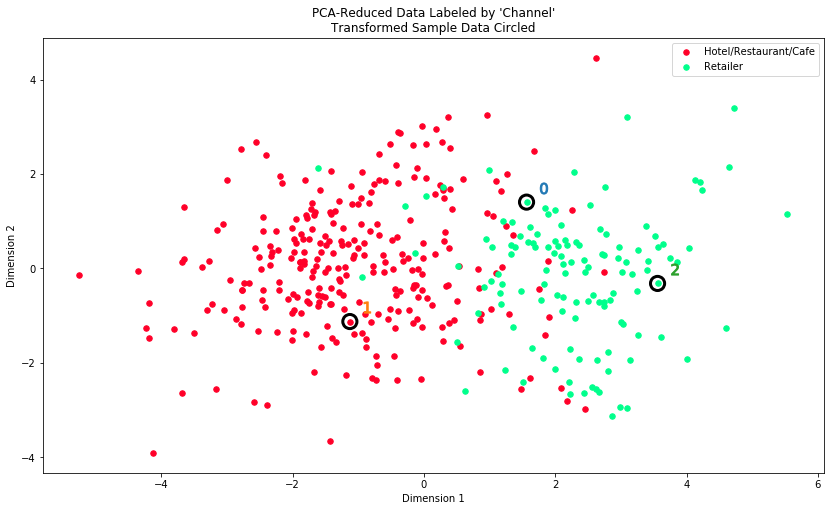

```python
# Display the clustering results based on 'Channel' data
vs.channel_results(reduced_data, outliers, pca_samples)
```

Sample point 0 best represented by cluster 1, which is a convenience store

Sample point 1 best represented by cluster 0, which is a restaurant

Sample point 2 best represented by cluster 1, which is a convenience store

### Observation 12

The clustering did a great job in clustering the channel type, all three sample prediction were correct. Even for sample point 0, which is really close to cluster 0, the clustering algorithm is able to get the correct type.

Based on the result, regarding there are few overlapping data points, in general, we can say that it is clear there are two clusters here, and a lot of the data points would classify purely as ‘Retailers’ or ‘Hotels/Restaurants/Cafes’ by this distribution.

Overall, I believe these classifications are consistent with my previous definition of the customer segments.